# HW6

Cameron Hall - camerhal@umich.edu

4/4/2022

2. Load house_prices.rda in R and perform the followings:
1. Use facet_wrap to draw line plots to represent the trend for house_price_index over years for each state. . Please have three ticks on the x axis which are for years 1980, 2000, and 2020. Since you have limited space your labels can be ’80, ’00, and ’20 for these ticks.
2. Use gather() function from tidyr to reshape your data in a way that it will have measure and value columns for house_price_index and unemploy_perc, respectively, in two columns. You should leave out remaining attributes by using ”-” in front them inside the function. Then, direct the output to a new data frame called house_reshaped Please refer to examples we did in class.
3. Use house_reshaped to replicate the graph in 2a with two lines where each represents house_price_index unemploy_perc over the years for each state. Once you have the chart, please comment on it as to whether it’s a good graph to present those two pieces of information.
4. When you achieve the goals above, please create a R markdown file and create an HTML page which has your codes and charts including your comments.

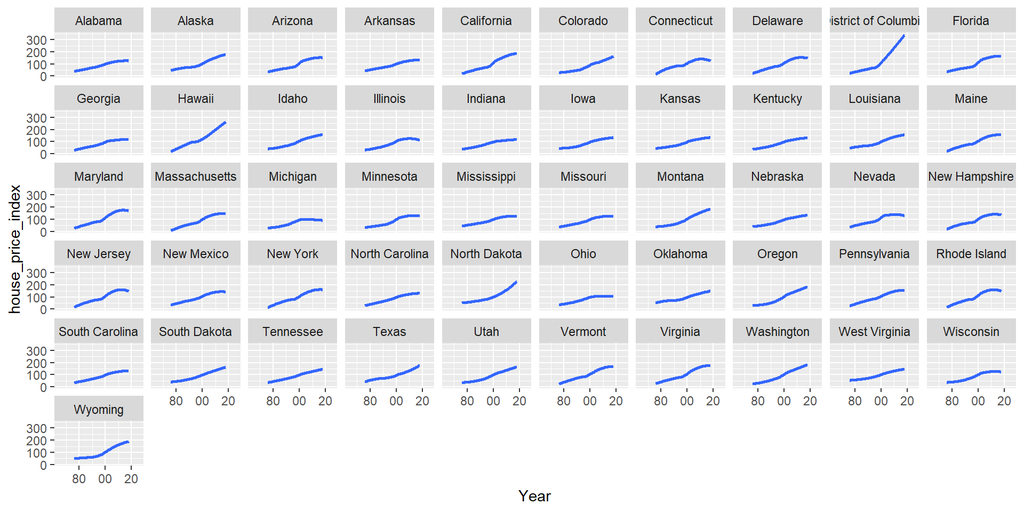

```r
library(ggplot2)
library(tidyr)

load("G:/.shortcut-targets-by-id/1ehWwunuAo7CE1Vk2JYkUnQMmxh5pph3C/DATA/house_prices.rda")
prices = house_prices


#2a
ggplot(data=prices, aes(x=date, y=house_price_index)) +
  geom_smooth() +
  facet_wrap(~state, ncol = 10) +
  scale_x_date(name='Year', date_breaks = '20 years', date_labels = '%y', limits = as.Date(c('1964-01-01', '2026-01-01'), breaks = as.Date(c('1980-01-01', '2020-01-01'))))
```

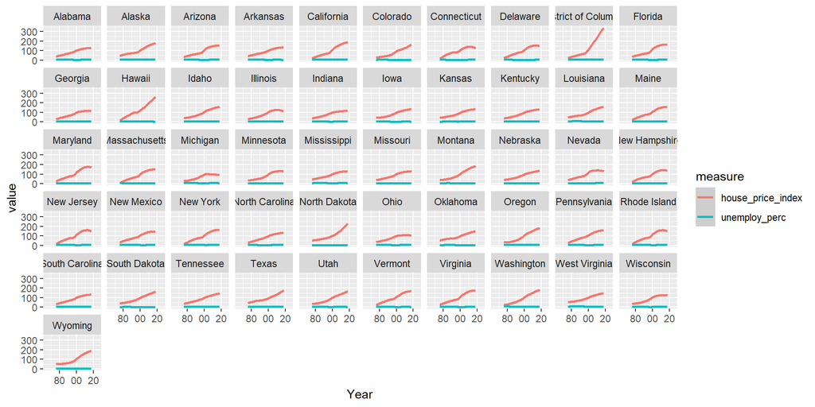

```r
#2b
house_reshaped <- gather(prices, measure, value, -1, -2, -5)

#2c
ggplot(data = house_reshaped, aes(x=date, y=value, group=measure, color=measure)) +
  geom_smooth() +
  facet_wrap(~state, ncol = 10) +
  scale_x_date(name='Year', date_breaks = '20 years', date_labels = '%y', limits = as.Date(c('1964-01-01', '2026-01-01'), breaks = as.Date(c('1980-01-01', '2020-01-01'))))
```

```r
#This is a poor graph to use to visualize these two data points. The values for house_price_index are significantly larger than values for unemploy_perc,
# making it difficult to compare these two. The unemploy_perc line appears almost flat because of a small scale.
```